# Xgboost_IEEE

## Simple example of parameter optimization of Xgboost through a Bayesian Optimization of (“rBayesianOptimization”) package.

The example is using a sample of the Vaihingen Dataset based on GEOBIA analysis. The GEOBIA procedures to process Vaihingen and any other raster dataset are documented in detail in : https://github.com/tgrippa/Opensource_OBIA_processing_chain

In this example we use a train and validation set extracted from Vaihingen tile 13. First we optimize the parameters of Xgboost, Support Vector Machines and Random Forest and then measure the predictions of the respective models through a confusion matrix with the validation data.

## Call relevant libraries

```r
library(randomForest)
library(xgboost)
library(e1071)
library(caret)
library(rBayesianOptimization)
library(readr)
library(Biocomb)
```

# The data contain several features extracted from the object-based segmentation (i.e., NDVI, VNIR, textures) that are used as input to the classification.

```r
kfold10 <- read_csv("D:/Xgboos_rev3/Newresults/kfold10.csv")
testlarge <- read_csv("D:/Xgboos_rev3/Newresults/testlarge.csv")
train=kfold10
test=testlarge
```

## Bayesian Optimization of Xgboost based on 10fold cross-validation.

## We predefine 600 trees and provide upper and lower ranges for the rest of the parameters

```r
cv_folds <- KFold(as.matrix(train$Class_Num), nfolds = 10, stratified = TRUE, seed = 0)
xgb_cv_bayes <- function(max_depth, min_child_weight,eta, subsample,colsample_bytree) {
  cv <- xgb.cv(params = list(booster = "dart", eta = eta,
                             max_depth = max_depth,
                             min_child_weight = min_child_weight,
                             subsample = subsample, colsample_bytree = colsample_bytree,
                             label=as.numeric(train$Class_Num),
                             objective="multi:softmax",
                             #objective="multi:softmax",
                             eval_metric="merror",
                             num_class=4)
                             ,
               data = as.matrix(train[,3:104]),label=as.matrix(train$Class_Num),
               nround=600,
               folds = cv_folds, prediction = TRUE, showsd = TRUE,
               early_stopping_rounds = 5,verbose = 0)
  list(Score = -cv$evaluation_log$test_merror_mean[cv$best_iteration],
       Pred = cv$pred)
}
OPT_Res <- BayesianOptimization(xgb_cv_bayes,
                                bounds = list(max_depth = c(2L, 7L),
                                              min_child_weight = c(1L, 7L),
                                              subsample = c(0.5, 0.9),
                                              eta=c(0.005,0.5),
                                              colsample_bytree=c(0.2,0.5)),
                                init_grid_dt = NULL, init_points = 10, n_iter = 70,
                                acq = "ucb", kappa = 2.576, eps = 0.0,
                                verbose = TRUE)
```

```
## elapsed = 8.89   Round = 1   max_depth = 3.0000  min_child_weight = 7.0000   subsample = 0.8291  eta = 0.4403    colsample_bytree = 0.4762   Value = -0.2269
## elapsed = 11.00  Round = 2   max_depth = 5.0000  min_child_weight = 7.0000   subsample = 0.6739  eta = 0.4682    colsample_bytree = 0.2125   Value = -0.2306
## elapsed = 2.45   Round = 3   max_depth = 3.0000  min_child_weight = 3.0000   subsample = 0.7059  eta = 0.0409    colsample_bytree = 0.2882   Value = -0.2850
## elapsed = 14.06  Round = 4   max_depth = 7.0000  min_child_weight = 5.0000   subsample = 0.7652  eta = 0.1925    colsample_bytree = 0.3503   Value = -0.2244
## elapsed = 10.11  Round = 5   max_depth = 6.0000  min_child_weight = 6.0000   subsample = 0.5573  eta = 0.2712    colsample_bytree = 0.3829   Value = -0.2369
## elapsed = 14.33  Round = 6   max_depth = 7.0000  min_child_weight = 5.0000   subsample = 0.6378  eta = 0.0570    colsample_bytree = 0.2793   Value = -0.2425
## elapsed = 8.72   Round = 7   max_depth = 6.0000  min_child_weight = 4.0000   subsample = 0.6623  eta = 0.4018    colsample_bytree = 0.3269   Value = -0.2369
## elapsed = 7.85   Round = 8   max_depth = 4.0000  min_child_weight = 4.0000   subsample = 0.5341  eta = 0.3711    colsample_bytree = 0.3100   Value = -0.2363
## elapsed = 18.61  Round = 9   max_depth = 6.0000  min_child_weight = 3.0000   subsample = 0.8730  eta = 0.0308    colsample_bytree = 0.4828   Value = -0.2462
## elapsed = 12.14  Round = 10  max_depth = 2.0000  min_child_weight = 5.0000   subsample = 0.8354  eta = 0.2437    colsample_bytree = 0.2371   Value = -0.2281
## elapsed = 13.10  Round = 11  max_depth = 5.0000  min_child_weight = 4.0000   subsample = 0.5745  eta = 0.2386    colsample_bytree = 0.5000   Value = -0.2225
## elapsed = 8.77   Round = 12  max_depth = 2.0000  min_child_weight = 1.0000   subsample = 0.7756  eta = 0.5000    colsample_bytree = 0.5000   Value = -0.2350
## elapsed = 12.67  Round = 13  max_depth = 4.0000  min_child_weight = 5.0000   subsample = 0.7674  eta = 0.1818    colsample_bytree = 0.2000   Value = -0.2244
## elapsed = 17.51  Round = 14  max_depth = 7.0000  min_child_weight = 4.0000   subsample = 0.5954  eta = 0.1701    colsample_bytree = 0.4473   Value = -0.2213
## elapsed = 8.86   Round = 15  max_depth = 4.0000  min_child_weight = 6.0000   subsample = 0.5431  eta = 0.3513    colsample_bytree = 0.4981   Value = -0.2300
## elapsed = 19.23  Round = 16  max_depth = 3.0000  min_child_weight = 3.0000   subsample = 0.8788  eta = 0.0725    colsample_bytree = 0.2855   Value = -0.2325
## elapsed = 12.36  Round = 17  max_depth = 3.0000  min_child_weight = 3.0000   subsample = 0.9000  eta = 0.1967    colsample_bytree = 0.2561   Value = -0.2238
## elapsed = 4.63   Round = 18  max_depth = 2.0000  min_child_weight = 4.0000   subsample = 0.5784  eta = 0.0240    colsample_bytree = 0.4079   Value = -0.3131
## elapsed = 16.19  Round = 19  max_depth = 7.0000  min_child_weight = 1.0000   subsample = 0.9000  eta = 0.5000    colsample_bytree = 0.5000   Value = -0.2338
## elapsed = 4.84   Round = 20  max_depth = 2.0000  min_child_weight = 5.0000   subsample = 0.5000  eta = 0.2581    colsample_bytree = 0.5000   Value = -0.2500
## elapsed = 11.11  Round = 21  max_depth = 4.0000  min_child_weight = 4.0000   subsample = 0.7670  eta = 0.2910    colsample_bytree = 0.5000   Value = -0.2275
## elapsed = 9.09   Round = 22  max_depth = 7.0000  min_child_weight = 3.0000   subsample = 0.5000  eta = 0.5000    colsample_bytree = 0.5000   Value = -0.2519
## elapsed = 3.75   Round = 23  max_depth = 2.0000  min_child_weight = 4.0000   subsample = 0.5000  eta = 0.5000    colsample_bytree = 0.5000   Value = -0.2575
## elapsed = 5.35   Round = 24  max_depth = 4.0000  min_child_weight = 4.0000   subsample = 0.9000  eta = 0.5000    colsample_bytree = 0.2000   Value = -0.2362
## elapsed = 10.22  Round = 25  max_depth = 2.0000  min_child_weight = 2.0000   subsample = 0.9000  eta = 0.1465    colsample_bytree = 0.5000   Value = -0.2444
## elapsed = 5.61   Round = 26  max_depth = 2.0000  min_child_weight = 7.0000   subsample = 0.7346  eta = 0.3927    colsample_bytree = 0.2000   Value = -0.2431
```

[output cut: 57 more lines]

# Parametrization of the cost and gamma parameters of SVM based on crossvalidation on exponential sequences.

In this example we use a coarse sequence but typically, another fine scale search is done around the coarse scale suggested parameters.

```r
svv_subset=train[,2:104]
SVM_param1<- tune.svm(Class_Num~., data = svv_subset, sampling = "fix",kernel='radial',
                  gamma = 2^(-10:-1), cost = 2^(-4:8))
SVM_param1
```

```
##
## Parameter tuning of 'svm':
##
## - sampling method: 10-fold cross validation
##
## - best parameters:
##     gamma cost
##  0.015625    1
##
## - best performance: 0.4888058
```

# Parametrization of the number of features sampled at each node for RF classifer

```
## mtry = 10  OOB error = 24.44%
## Searching left ...
## mtry = 5     OOB error = 24.75%
## -0.01278772 0.05
## Searching right ...
## mtry = 20    OOB error = 23.94%
## 0.02046036 0.05
```

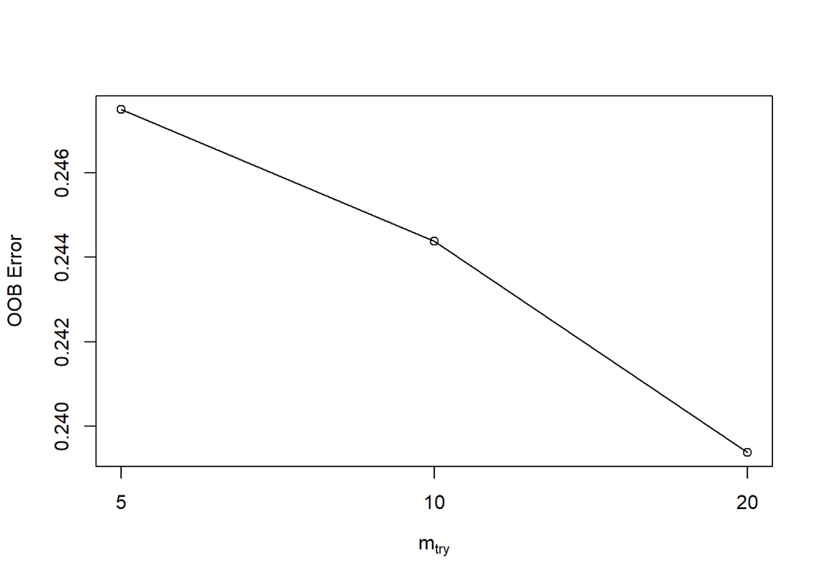

```r
Tune_rf_1=Tune_rf=tuneRF(as.matrix(train[,3:104]), factor(train$Class_Num), ntreeTry=1000, stepFactor=2, improve=0.05,
       trace=TRUE, plot=TRUE, doBest=FALSE)
```

Training the Xgboost classifier with the specified parameters from the Bayesian optmization and measuring the classification accuracy through the validation data.

```r
num_class <- 4
lb <- as.numeric(train$Class_Num)
bst <- xgboost(data = as.matrix(train[,3:104]),print_every_n = 300 ,objective="multi:softmax",eval_metric="merror",nrounds=600,eta=OPT_Res$Best_Par[4],booster="dart",max_depth=OPT_Res$Best_Par[1],min_child_weight=OPT_Res$Best_Par[2],subsample=OPT_Res$Best_Par[3],colsample_bytree=OPT_Res$Best_Par[5],gamma=0.00, num_class = num_class,label=lb)
pred <- predict(bst, as.matrix(test[,3:104]))
pred.softmax.df= as.data.frame(pred)
xtab <- table(pred.softmax.df$pred, test$Class_Num)
Xgboost_CM=confusionMatrix(xtab)
Xgboost_CM
```

```
## Confusion Matrix and Statistics
##
##
##       0   1   2   3
##   0 802  67 116  31
##   1  54 889  33  11
##   2 108  44 604 196
##   3  36   0 247 762
##
## Overall Statistics
##
##                Accuracy : 0.7642
##                  95% CI : (0.7508, 0.7773)
##     No Information Rate : 0.25
##     P-Value [Acc > NIR] : < 2.2e-16
##
##                   Kappa : 0.6857
##  Mcnemar's Test P-Value : 0.002257
##
## Statistics by Class:
##
##                      Class: 0 Class: 1 Class: 2 Class: 3
## Sensitivity            0.8020   0.8890   0.6040   0.7620
## Specificity            0.9287   0.9673   0.8840   0.9057
## Pos Pred Value         0.7894   0.9007   0.6345   0.7292
## Neg Pred Value         0.9336   0.9632   0.8701   0.9195
## Prevalence             0.2500   0.2500   0.2500   0.2500
## Detection Rate         0.2005   0.2223   0.1510   0.1905
## Detection Prevalence   0.2540   0.2467   0.2380   0.2612
## Balanced Accuracy      0.8653   0.9282   0.7440   0.8338
```

Training the SVM classifier with the specified parameters from the grid search and measuring the classification accuracy through the validation data.

```r
svm.model <- svm(as.matrix(train[3:104]),train$Class_Num,type="C-classification",gamma=SVM_param1$best.parameters[1],cost=SVM_param1$best.parameters[2])
svm.pred <- predict(svm.model, as.matrix(test[,3:104]),decision.values = TRUE)
svmtable=table(svm.pred,test$Class_Num)
SVM_CM=confusionMatrix(svmtable)
SVM_CM
```

```
## Confusion Matrix and Statistics
##
##
## svm.pred   0   1   2   3
##        0 661 159 152  23
##        1 129 820  34   6
##        2 179  21 533 192
##        3  31   0 281 779
##
## Overall Statistics
##
##                Accuracy : 0.6982
##                  95% CI : (0.6838, 0.7125)
##     No Information Rate : 0.25
##     P-Value [Acc > NIR] : < 2.2e-16
##
##                   Kappa : 0.5977
##  Mcnemar's Test P-Value : 1.409e-05
##
## Statistics by Class:
##
##                      Class: 0 Class: 1 Class: 2 Class: 3
## Sensitivity            0.6610   0.8200   0.5330   0.7790
## Specificity            0.8887   0.9437   0.8693   0.8960
## Pos Pred Value         0.6643   0.8291   0.5762   0.7140
## Neg Pred Value         0.8872   0.9402   0.8481   0.9240
## Prevalence             0.2500   0.2500   0.2500   0.2500
## Detection Rate         0.1653   0.2050   0.1333   0.1948
## Detection Prevalence   0.2487   0.2472   0.2313   0.2727
## Balanced Accuracy      0.7748   0.8818   0.7012   0.8375
```

Training the RF classifier parametrized the grid search and measuring the classification accuracy through the validation data. 500 trees were sufficient for this example.

```r
train_vsurf_rf <- randomForest(as.factor(train$Class_Num) ~ ., data=train[,3:104],ntree=500,mtry=20,importance=TRUE)
pred=predict(train_vsurf_rf, as.matrix(test[,3:104]))
rftable2=table(pred,as.factor(test$Class_Num))
RF_CM=confusionMatrix(rftable2)
RF_CM
```

```
## Confusion Matrix and Statistics
##
##
## pred   0   1   2   3
##    0 759  83 131  26
##    1  64 887  46   7
##    2 143  30 565 218
##    3  34   0 258 749
##
## Overall Statistics
##
##                Accuracy : 0.74
##                  95% CI : (0.7261, 0.7535)
##     No Information Rate : 0.25
##     P-Value [Acc > NIR] : < 2.2e-16
##
##                   Kappa : 0.6533
##  Mcnemar's Test P-Value : 0.006812
##
## Statistics by Class:
##
##                      Class: 0 Class: 1 Class: 2 Class: 3
## Sensitivity            0.7590   0.8870   0.5650   0.7490
## Specificity            0.9200   0.9610   0.8697   0.9027
## Pos Pred Value         0.7598   0.8835   0.5910   0.7195
## Neg Pred Value         0.9197   0.9623   0.8571   0.9152
## Prevalence             0.2500   0.2500   0.2500   0.2500
## Detection Rate         0.1898   0.2218   0.1412   0.1872
## Detection Prevalence   0.2497   0.2510   0.2390   0.2602
## Balanced Accuracy      0.8395   0.9240   0.7173   0.8258
```

```r
CSFS_mat=cbind(as.data.frame(train[ ,3:104]),as.data.frame((train[ ,2])))
colnames(CSFS_mat)[103] <- "Class_Num"
CSFS_mat$Class_Num= as.factor(CSFS_mat$Class_Num)
CSFS1= select.cfs(matrix=CSFS_mat)
CSFS1$Biomarker= as.character(CSFS1$Biomarker)
rankking_CSF=CSFS1$Biomarker
CFS_train <- CSFS_mat[, rankking_CSF]
CSF_test= testlarge[, rankking_CSF]
```

Optimizing Xgboost after CFS feature selection through Bayesian Optimization.

```r
cv_folds <- KFold(as.matrix(train$Class_Num), nfolds = 10, stratified = TRUE, seed = 0)
xgb_cv_bayes <- function(max_depth, min_child_weight,eta, subsample,colsample_bytree) {
  cv <- xgb.cv(params = list(booster = "dart", eta = eta,
                             max_depth = max_depth,
                             min_child_weight = min_child_weight,
                             subsample = subsample, colsample_bytree = colsample_bytree,
                             label=as.numeric(train$Class_Num),
                             objective="multi:softmax",
                             #objective="multi:softmax",
                             eval_metric="merror",
                             num_class=4)
                             ,
               data = as.matrix(CFS_train[,1:12]),label=as.matrix(train$Class_Num),
               nround=600,
               folds = cv_folds, prediction = TRUE, showsd = TRUE,
               early_stopping_rounds = 5,verbose = 0)
  list(Score = -cv$evaluation_log$test_merror_mean[cv$best_iteration],
       Pred = cv$pred)
}
OPT_Res_CFS <- BayesianOptimization(xgb_cv_bayes,
                                bounds = list(max_depth = c(2L, 7L),
                                              min_child_weight = c(1L, 7L),
                                              subsample = c(0.5, 0.9),
                                              eta=c(0.005,0.5),
                                              colsample_bytree=c(0.2,0.5)),
                                init_grid_dt = NULL, init_points = 10, n_iter = 70,
                                acq = "ucb", kappa = 2.576, eps = 0.0,
                                verbose = TRUE)
```

```
## elapsed = 7.20   Round = 1   max_depth = 3.0000  min_child_weight = 7.0000   subsample = 0.8291  eta = 0.4403    colsample_bytree = 0.4762   Value = -0.2575
## elapsed = 7.22   Round = 2   max_depth = 5.0000  min_child_weight = 7.0000   subsample = 0.6739  eta = 0.4682    colsample_bytree = 0.2125   Value = -0.2762
## elapsed = 5.17   Round = 3   max_depth = 3.0000  min_child_weight = 3.0000   subsample = 0.7059  eta = 0.0409    colsample_bytree = 0.2882   Value = -0.3056
## elapsed = 13.78  Round = 4   max_depth = 7.0000  min_child_weight = 5.0000   subsample = 0.7652  eta = 0.1925    colsample_bytree = 0.3503   Value = -0.2444
## elapsed = 6.14   Round = 5   max_depth = 6.0000  min_child_weight = 6.0000   subsample = 0.5573  eta = 0.2712    colsample_bytree = 0.3829   Value = -0.2631
## elapsed = 7.67   Round = 6   max_depth = 7.0000  min_child_weight = 5.0000   subsample = 0.6378  eta = 0.0570    colsample_bytree = 0.2793   Value = -0.2687
## elapsed = 11.10  Round = 7   max_depth = 6.0000  min_child_weight = 4.0000   subsample = 0.6623  eta = 0.4018    colsample_bytree = 0.3269   Value = -0.2587
## elapsed = 5.39   Round = 8   max_depth = 4.0000  min_child_weight = 4.0000   subsample = 0.5341  eta = 0.3711    colsample_bytree = 0.3100   Value = -0.2669
## elapsed = 7.45   Round = 9   max_depth = 6.0000  min_child_weight = 3.0000   subsample = 0.8730  eta = 0.0308    colsample_bytree = 0.4828   Value = -0.2675
## elapsed = 9.14   Round = 10  max_depth = 2.0000  min_child_weight = 5.0000   subsample = 0.8354  eta = 0.2437    colsample_bytree = 0.2371   Value = -0.2700
## elapsed = 7.67   Round = 11  max_depth = 4.0000  min_child_weight = 4.0000   subsample = 0.5766  eta = 0.0686    colsample_bytree = 0.4025   Value = -0.2775
## elapsed = 8.28   Round = 12  max_depth = 6.0000  min_child_weight = 5.0000   subsample = 0.5221  eta = 0.5000    colsample_bytree = 0.3274   Value = -0.2569
## elapsed = 12.84  Round = 13  max_depth = 7.0000  min_child_weight = 7.0000   subsample = 0.6071  eta = 0.2377    colsample_bytree = 0.3887   Value = -0.2469
## elapsed = 8.25   Round = 14  max_depth = 7.0000  min_child_weight = 3.0000   subsample = 0.5839  eta = 0.4818    colsample_bytree = 0.3579   Value = -0.2512
## elapsed = 10.52  Round = 15  max_depth = 3.0000  min_child_weight = 5.0000   subsample = 0.6413  eta = 0.1322    colsample_bytree = 0.4669   Value = -0.2650
## elapsed = 8.39   Round = 16  max_depth = 6.0000  min_child_weight = 5.0000   subsample = 0.5593  eta = 0.4295    colsample_bytree = 0.3058   Value = -0.2606
## elapsed = 8.99   Round = 17  max_depth = 3.0000  min_child_weight = 6.0000   subsample = 0.6081  eta = 0.2488    colsample_bytree = 0.3373   Value = -0.2581
## elapsed = 11.78  Round = 18  max_depth = 7.0000  min_child_weight = 5.0000   subsample = 0.8830  eta = 0.2632    colsample_bytree = 0.2410   Value = -0.2625
## elapsed = 5.80   Round = 19  max_depth = 2.0000  min_child_weight = 5.0000   subsample = 0.7275  eta = 0.3144    colsample_bytree = 0.4239   Value = -0.2637
## elapsed = 11.26  Round = 20  max_depth = 6.0000  min_child_weight = 2.0000   subsample = 0.6915  eta = 0.5000    colsample_bytree = 0.4818   Value = -0.2431
## elapsed = 13.69  Round = 21  max_depth = 7.0000  min_child_weight = 7.0000   subsample = 0.7022  eta = 0.4079    colsample_bytree = 0.5000   Value = -0.2387
## elapsed = 17.29  Round = 22  max_depth = 7.0000  min_child_weight = 4.0000   subsample = 0.8806  eta = 0.1610    colsample_bytree = 0.5000   Value = -0.2475
## elapsed = 5.49   Round = 23  max_depth = 5.0000  min_child_weight = 3.0000   subsample = 0.7055  eta = 0.4171    colsample_bytree = 0.5000   Value = -0.2487
## elapsed = 10.55  Round = 24  max_depth = 7.0000  min_child_weight = 4.0000   subsample = 0.7409  eta = 0.4737    colsample_bytree = 0.5000   Value = -0.2519
## elapsed = 11.33  Round = 25  max_depth = 5.0000  min_child_weight = 4.0000   subsample = 0.8721  eta = 0.5000    colsample_bytree = 0.5000   Value = -0.2406
## elapsed = 9.43   Round = 26  max_depth = 7.0000  min_child_weight = 7.0000   subsample = 0.5256  eta = 0.3295    colsample_bytree = 0.5000   Value = -0.2656
```

[output cut: 57 more lines]

Training the Xgboost classifier after FS with the specified parameters from the Bayesian optmization and measuring the classification accuracy through the validation data.

```r
num_class <- 4
lb <- as.numeric(train$Class_Num)
bst <- xgboost(data = as.matrix(CFS_train[,1:14]),print_every_n = 300 ,objective="multi:softmax",eval_metric="merror",nrounds=600,eta=OPT_Res_CFS$Best_Par[4],booster="dart",max_depth=OPT_Res_CFS$Best_Par[1],min_child_weight=OPT_Res_CFS$Best_Par[2],subsample=OPT_Res_CFS$Best_Par[3],colsample_bytree=OPT_Res_CFS$Best_Par[5],gamma=0.00, num_class = num_class,label=lb)
pred <- predict(bst, as.matrix(CSF_test[,1:14]))
pred.softmax.df= as.data.frame(pred)
xtab <- table(pred.softmax.df$pred, test$Class_Num)
Xgboost_CM_CFS=confusionMatrix(xtab)
Xgboost_CM_CFS
```

```
## Confusion Matrix and Statistics
##
##
##       0   1   2   3
##   0 804  74 117  38
##   1  61 878  45  11
##   2  96  47 606 236
##   3  39   1 232 715
##
## Overall Statistics
##
##                Accuracy : 0.7508
##                  95% CI : (0.737, 0.7641)
##     No Information Rate : 0.25
##     P-Value [Acc > NIR] : < 2e-16
##
##                   Kappa : 0.6677
##  Mcnemar's Test P-Value : 0.06787
##
## Statistics by Class:
##
##                      Class: 0 Class: 1 Class: 2 Class: 3
## Sensitivity            0.8040   0.8780   0.6060   0.7150
## Specificity            0.9237   0.9610   0.8737   0.9093
## Pos Pred Value         0.7783   0.8824   0.6152   0.7244
## Neg Pred Value         0.9339   0.9594   0.8693   0.9054
## Prevalence             0.2500   0.2500   0.2500   0.2500
## Detection Rate         0.2010   0.2195   0.1515   0.1787
## Detection Prevalence   0.2582   0.2487   0.2462   0.2467
## Balanced Accuracy      0.8638   0.9195   0.7398   0.8122
```

Optimizing Random Forest after Feature Selection

```
## mtry = 3  OOB error = 24.62%
## Searching left ...
## mtry = 2     OOB error = 25.06%
## -0.0177665 0.05
## Searching right ...
## mtry = 6     OOB error = 25%
## -0.01522843 0.05
```

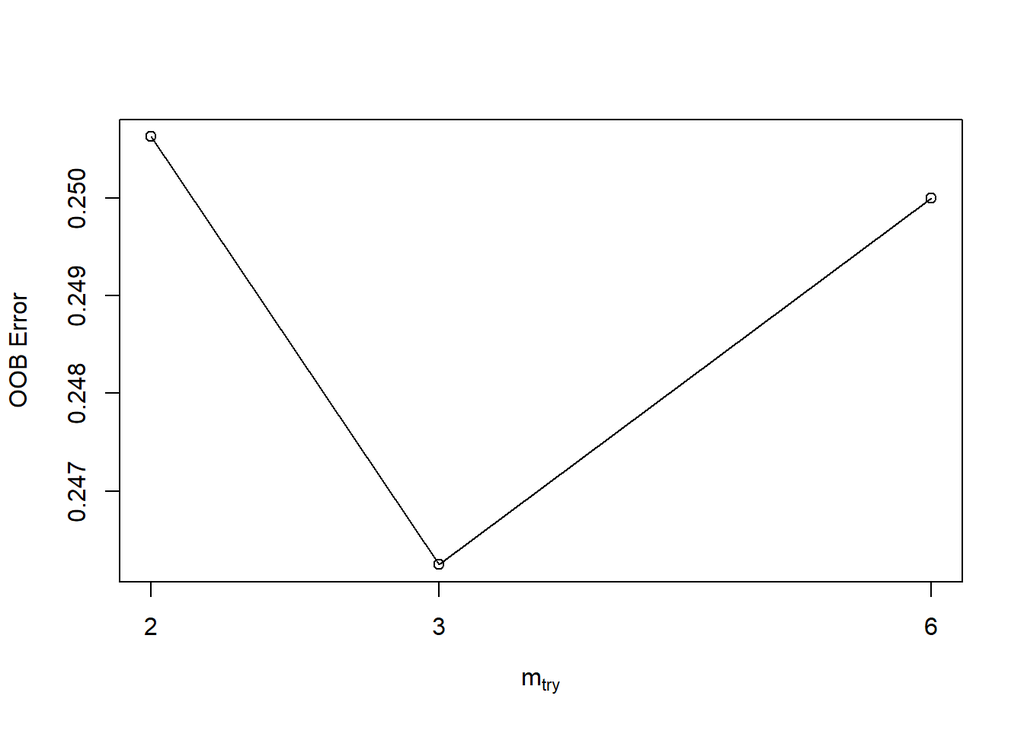

```r
Tune_RF_CFS=tuneRF(as.matrix(CFS_train[,1:14]), factor(train$Class_Num), ntreeTry=1000, stepFactor=2, improve=0.05,
       trace=TRUE, plot=TRUE, doBest=FALSE)
```

```r
train_vsurf_rf <- randomForest(as.factor(train$Class_Num) ~ ., data=CFS_train[,1:14],ntree=500,mtry=6,importance=TRUE)
pred=predict(train_vsurf_rf, as.matrix(CSF_test[,1:14]))
rftable2=table(pred,as.factor(test$Class_Num))
RF_CM_CFS=confusionMatrix(rftable2)
RF_CM_CFS
```

```
## Confusion Matrix and Statistics
##
##
## pred   0   1   2   3
##    0 765  77 122  30
##    1  74 890  53   6
##    2 126  33 558 210
##    3  35   0 267 754
##
## Overall Statistics
##
##                Accuracy : 0.7418
##                  95% CI : (0.7279, 0.7553)
##     No Information Rate : 0.25
##     P-Value [Acc > NIR] : < 2.2e-16
##
##                   Kappa : 0.6557
##  Mcnemar's Test P-Value : 0.006305
##
## Statistics by Class:
##
##                      Class: 0 Class: 1 Class: 2 Class: 3
## Sensitivity            0.7650   0.8900   0.5580   0.7540
## Specificity            0.9237   0.9557   0.8770   0.8993
## Pos Pred Value         0.7696   0.8700   0.6019   0.7140
## Neg Pred Value         0.9218   0.9631   0.8562   0.9164
## Prevalence             0.2500   0.2500   0.2500   0.2500
## Detection Rate         0.1913   0.2225   0.1395   0.1885
## Detection Prevalence   0.2485   0.2557   0.2318   0.2640
## Balanced Accuracy      0.8443   0.9228   0.7175   0.8267
```

```r
svm_cfs_subset=cbind(CFS_train,train$Class_Num)
colnames(svm_cfs_subset)[15] <- "Class_Num"
SVM_param_CFS<- tune.svm(Class_Num~., data = svm_cfs_subset, sampling = "fix",kernel='radial',
                  gamma = 2^(-10:-1), cost = 2^(-4:8))
SVM_param_CFS
```

```
##
## Parameter tuning of 'svm':
##
## - sampling method: 10-fold cross validation
##
## - best parameters:
##       gamma cost
##  0.00390625  128
##
## - best performance: 0.0003556167
```

```r
svm.model <- svm(as.matrix(svm_cfs_subset[,1:14]),train$Class_Num,type="C-classification",gamma=SVM_param_CFS$best.parameters[1],cost=SVM_param_CFS$best.parameters[2])
svm.pred <- predict(svm.model, as.matrix(CSF_test[,1:14]),decision.values = TRUE)
svmtable=table(svm.pred,test$Class_Num)
SVM_CM_CFS=confusionMatrix(svmtable)
SVM_CM_CFS
```

```
## Confusion Matrix and Statistics
##
##
## svm.pred   0   1   2   3
##        0 685 202 178  28
##        1  85 778  40   7
##        2 201  20 511 215
##        3  29   0 271 750
##
## Overall Statistics
##
##                Accuracy : 0.681
##                  95% CI : (0.6663, 0.6954)
##     No Information Rate : 0.25
##     P-Value [Acc > NIR] : < 2.2e-16
##
##                   Kappa : 0.5747
##  Mcnemar's Test P-Value : 5.883e-13
##
## Statistics by Class:
##
##                      Class: 0 Class: 1 Class: 2 Class: 3
## Sensitivity            0.6850   0.7780   0.5110   0.7500
## Specificity            0.8640   0.9560   0.8547   0.9000
## Pos Pred Value         0.6267   0.8549   0.5396   0.7143
## Neg Pred Value         0.8916   0.9282   0.8398   0.9153
## Prevalence             0.2500   0.2500   0.2500   0.2500
## Detection Rate         0.1713   0.1945   0.1278   0.1875
## Detection Prevalence   0.2732   0.2275   0.2367   0.2625
## Balanced Accuracy      0.7745   0.8670   0.6828   0.8250
```